# Factors

## Factors

A `factor` is a special `character` vector where the elements have pre-defined groups or ‘levels’. You can think of these as qualitative or categorical variables:

```r
x <- c("yellow", "red", "red", "blue", "yellow", "blue")
class(x)
```

```
## [1] "character"
```

```r
x_fact <- factor(x) # factor() is a function
class(x_fact)
```

```
## [1] "factor"
```

## Factors

Factors have **levels** (character types do not).

```r
x
```

```
## [1] "yellow" "red"    "red"    "blue"   "yellow" "blue"
```

```r
x_fact
```

```
## [1] yellow red    red    blue   yellow blue
## Levels: blue red yellow
```

Note that levels are, by default, in **alphanumerical** order.

## Factors

Extract the levels of a `factor` vector using `levels()`:

```r
levels(x_fact)
```

```
## [1] "blue"   "red"    "yellow"
```

## `forcats` package

A package called `forcats` is really helpful for working with factors.

## `factor()` vs `as_factor()`

`factor()` is from base R and `as_factor()` is from `forcats`

Both can change a variable to be of class factor.

- `factor()` will order **alphanumerically** unless told otherwise.
- `as_factor()` will order by **first appearance** unless told otherwise.

If you are assigning your levels manually either function is fine!

## `as_factor()` function

```r
x <- c("yellow", "red", "red", "blue", "yellow", "blue")
x_fact_2 <- as_factor(x)
x_fact_2
```

```
## [1] yellow red    red    blue   yellow blue
## Levels: yellow red blue
```

```r
# Compare to factor() method:
x_fact
```

```
## [1] yellow red    red    blue   yellow blue
## Levels: blue red yellow
```

## A Factor Example

We will use a slightly different version of the data on heat-related visits to the ER from the State of Colorado.

For today, we are looking at data that reports ER visits by age category.

```r
er_visits_age <- read_csv("https://daseh.org/data/CO_ER_heat_visits_by_age.csv")
```

## The data

```r
head(er_visits_age)
```

```
## # A tibble: 6 × 6
##    year age          rate lower95cl upper95cl visits
##   <dbl> <chr>       <dbl>     <dbl>     <dbl>  <dbl>
## 1  2011 0-4 years    3.52      1.82      6.16     12
## 2  2011 15-34 years  7.34      5.95      8.74    106
## 3  2011 35-64 years  5.84      4.80      6.88    121
## 4  2011 5-14 years   5.20      3.50      6.90     36
## 5  2011 65+ years    8.34      5.98     10.7      48
## 6  2012 0-4 years    3.58      1.85      6.25     12
```

Notice that `age` is a `chr` variable. This indicates that the values are **character** strings.

R does not realize that there is any order related to the `AGE` values. It will assume that it is **alphanumeric** (for numbers, this means ascending order).

However, we know that the order is: **0-4 years old**, **5-14 years old**, **15-34 years old**, **35-64 years old**, and **65+ years old**.

## For the next steps, let’s take a subset of data.

Use `set.seed()` to take the same random sample each time.

```r
set.seed(123)
er_visits_age_subset <- slice_sample(er_visits_age, n = 32)
```

## Plot the data

Let’s make a plot first.

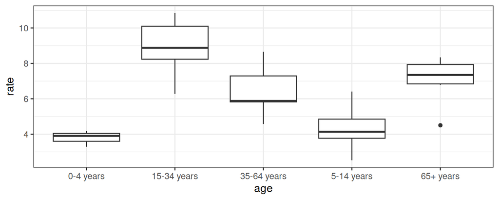

```r
er_visits_age_subset |>
  ggplot(aes(x = age, y = rate)) +
  geom_boxplot() +
  theme_bw(base_size = 12) # make all labels size 12
```

OK this is very useful, but it is a bit difficult to read. We expect the values to be plotted by the order that we know, not by alphabetical order.

## Change to factor

Currently `age` is class `character` but let’s change that to class `factor` which allows us to specify the levels or order of the values.

```r
er_visits_age_fct <-
  er_visits_age_subset |>
  mutate(age = factor(age,
    levels = c("0-4 years", "5-14 years", "15-34 years", "35-64 years",
               "65+ years")
  ))

er_visits_age_fct |>
  pull(age) |>
  levels()
```

```
## [1] "0-4 years"   "5-14 years"  "15-34 years" "35-64 years" "65+ years"
```

## Change to a factor

```r
head(er_visits_age_fct)
```

```
## # A tibble: 6 × 6
##    year age          rate lower95cl upper95cl visits
##   <dbl> <fct>       <dbl>     <dbl>     <dbl>  <dbl>
## 1  2017 0-4 years    3.29      1.64      5.89     11
## 2  2013 65+ years    4.50      2.86      6.14     29
## 3  2021 0-4 years   NA        NA        NA        NA
## 4  2013 5-14 years   5.51      3.78      7.23     39
## 5  2011 35-64 years  5.84      4.80      6.88    121
## 6  2019 15-34 years  8.34      6.94      9.73    137
```

## Plot again

Now let’s make our plot again:

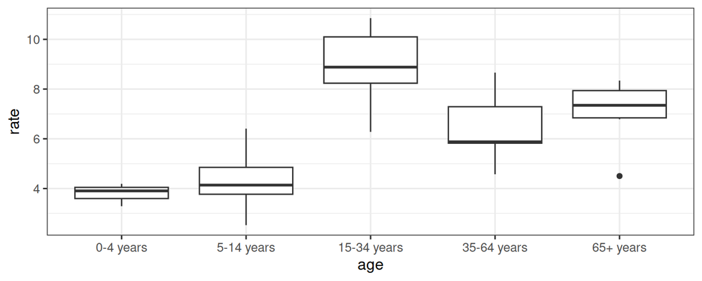

```r
er_visits_age_fct |>
  ggplot(aes(x = age, y = rate)) +
  geom_boxplot() +
  theme_bw(base_size = 12)
```

Now that’s more like it! Notice how the data is automatically plotted in the order we would like.

## What about if we `arrange()` the data by age?

Character data is arranged alphabetically (if letters) or by ascending first number (if numbers).

```r
er_visits_age_subset |>
  arrange(age)
```

```
## # A tibble: 32 × 6
##     year age          rate lower95cl upper95cl visits
##    <dbl> <chr>       <dbl>     <dbl>     <dbl>  <dbl>
##  1  2017 0-4 years    3.29      1.64      5.89     11
##  2  2021 0-4 years   NA        NA        NA        NA
##  3  2016 0-4 years    4.19      2.29      7.03     14
##  4  2018 0-4 years    3.91      2.08      6.68     13
##  5  2019 15-34 years  8.34      6.94      9.73    137
##  6  2018 15-34 years 10.1       8.60     11.7     165
##  7  2022 15-34 years 10.0       8.52     11.6     167
##  8  2016 15-34 years 10.9       9.23     12.5     171
##  9  2012 15-34 years  8.88      7.36     10.4     130
## 10  2014 15-34 years  6.28      5.02      7.54     95
## # ℹ 22 more rows
```

Notice that the order is not what we would hope for!

## Arranging Factors

Factor data is arranged by level.

```r
er_visits_age_fct |>
  arrange(age)
```

```
## # A tibble: 32 × 6
##     year age         rate lower95cl upper95cl visits
##    <dbl> <fct>      <dbl>     <dbl>     <dbl>  <dbl>
##  1  2017 0-4 years   3.29      1.64      5.89     11
##  2  2021 0-4 years  NA        NA        NA        NA
##  3  2016 0-4 years   4.19      2.29      7.03     14
##  4  2018 0-4 years   3.91      2.08      6.68     13
##  5  2013 5-14 years  5.51      3.78      7.23     39
##  6  2012 5-14 years  4.14      2.63      5.64     29
##  7  2016 5-14 years  6.41      4.56      8.26     46
##  8  2020 5-14 years NA        NA        NA        NA
##  9  2019 5-14 years  3.80      2.36      5.23     27
## 10  2014 5-14 years  2.53      1.50      3.99     18
## # ℹ 22 more rows
```

Nice! Now this is what we would want!

## Making tables with characters

Tables grouped by a character are arranged alphabetically (if letters) or by ascending first number (if numbers).

```r
er_visits_age_subset |>
  group_by(age) |>
  summarize(total_visits = sum(visits, na.rm = T))
```

```
## # A tibble: 5 × 2
##   age         total_visits
##   <chr>              <dbl>
## 1 0-4 years             38
## 2 15-34 years          986
## 3 35-64 years          983
## 4 5-14 years           215
## 5 65+ years            296
```

## Making tables with factors

Tables grouped by a factor are arranged by level.

```r
er_visits_age_fct |>
  group_by(age) |>
  summarize(total_visits = sum(visits, na.rm = T))
```

```
## # A tibble: 5 × 2
##   age         total_visits
##   <fct>              <dbl>
## 1 0-4 years             38
## 2 5-14 years           215
## 3 15-34 years          986
## 4 35-64 years          983
## 5 65+ years            296
```

## `forcats` for ordering

What if we wanted to order `age` by increasing `rate`?

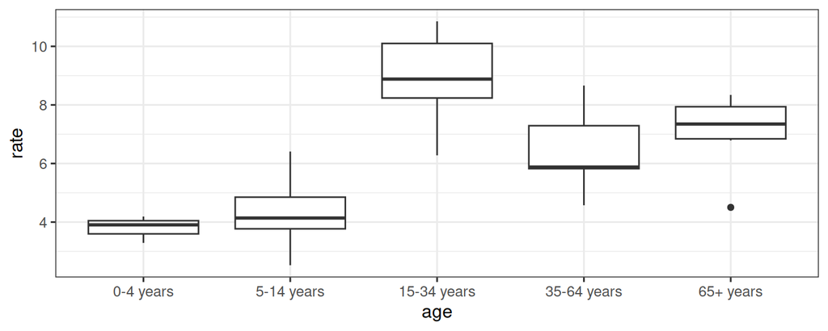

```r
library(forcats)

er_visits_age_fct |>
  ggplot(aes(x = age, y = rate)) +
  geom_boxplot() +
  theme_bw(base_size = 12)
```

This would be useful for identifying easily which age group to focus on.

## forcats for ordering

We can order a factor by another variable by using the `fct_reorder()` function of the `forcats` package.

```r
fct_reorder({column getting changed}, {guiding column}, {summarizing function})
```

## forcats for ordering

We can order a factor by another variable by using the `fct_reorder()` function of the `forcats` package.

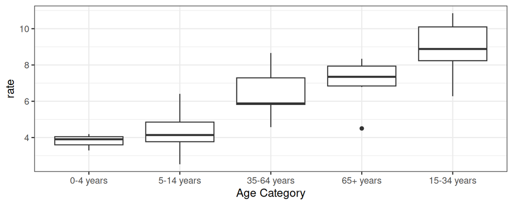

```r
library(forcats)

er_visits_age_fct |>
  ggplot(aes(x = fct_reorder(age, rate, mean), y = rate)) +
  geom_boxplot() +
  labs(x = "Age Category") +
  theme_bw(base_size = 12)
```

## forcats for ordering.. with `.desc =` argument

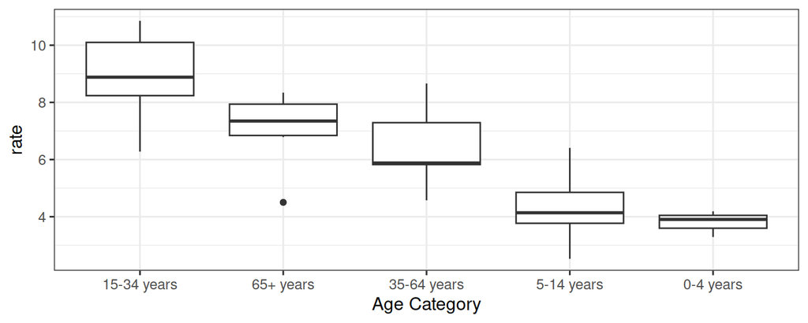

```r
library(forcats)

er_visits_age_fct |>
  ggplot(aes(x = fct_reorder(age, rate, mean, .desc = TRUE), y = rate)) +
  geom_boxplot() +
  labs(x = "Age Category") +
  theme_bw(base_size = 12)
```

## forcats for ordering… can be used to sort datasets

```r
er_visits_age_fct |> pull(age) |> levels() # By year order
```

```
## [1] "0-4 years"   "5-14 years"  "15-34 years" "35-64 years" "65+ years"
```

```r
er_visits_age_fct <- er_visits_age_fct |>
  mutate(
    age = fct_reorder(age, rate, mean)
  )

er_visits_age_fct |> pull(age) |> levels() # by increasing mean visits
```

```
## [1] "0-4 years"   "5-14 years"  "35-64 years" "65+ years"   "15-34 years"
```

## Checking Proportions with `fct_count()`

The `fct_count()` function of the `forcats` package is helpful for checking that the proportions of each level for a factor are similar. Need the `prop = TRUE` argument otherwise just counts are reported.

```r
er_visits_age_fct |>
  pull(age) |>
  fct_count(prop = TRUE)
```

```
## # A tibble: 5 × 3
##   f               n     p
##   <fct>       <int> <dbl>
## 1 0-4 years       4 0.125
## 2 5-14 years      8 0.25
## 3 35-64 years     7 0.219
## 4 65+ years       6 0.188
## 5 15-34 years     7 0.219
```

## GUT CHECK: Why is it useful to have the factor class as an option?

A. It helps us check the factual accuracy of our datasets.

B. It helps us change the order of variables in case the order has meaning.

## GUT CHECK: What does the `fct_reorder()` function do?

A. It helps us reorder a factor based on the values of another variable.

B. It helps us reorder a factor based on a random change in the order.

## Summary

- the factor class allows us to have a different order from alphanumeric for categorical data
- we can change data to be a factor variable using `mutate` and a factor creating function like `factor()` or `as_factor`
- the `as_factor()` is from the `forcats` package (first appearance order by default)
- the `factor()` base R function (alphanumeric order by default)
- with `factor()` we can specify the levels with the `levels` argument if we want a specific order
- the `fct_reorder({variable_to_reorder}, {variable_to_order_by}, {summary function})` helps us reorder a variable by the values of another variable
- arranging, tabulating, and plotting the data will reflect the new order

## Lab

🏠 [Class Website](https://daseh.org/)  
💻 [Lab](https://daseh.org/modules//Factors/lab/Factors_Lab.Rmd). 📃[Day 6 Cheatsheet](https://daseh.org/modules/cheatsheets/Day-6.pdf) 📃[Posit’s forcats cheatsheet](https://rstudio.github.io/cheatsheets/factors.pdf)